# Backdating: how mining onset years are dated, and how well

Till Meissner

2026-11-25

# Summary

**What this is.** We want to know when mining began on land that is mined today. The embeddings classifier maps mining only from 2017 on. So we take every pixel mined in 2017 (confirmed: also mined in 2018, see `diag_03_embedding_product_report`), look back through the Landsat archive (1998-2018) for the year its vegetation was cleared, and impute that as the pixel’s conversion year (“onset”). Joined with the classifier’s first confirmed detections from 2018, this gives one onset series for 2000-2025, which feeds the panel.

- **Method:** the Barenblitt-replica NDVI method (Section 1), with years that have only one clear image filled in from their neighbours (rule e, Section 1.3), dates every pixel mined by 2017 to an onset year, 2000-2017. The validation numbers in this summary are for the plain replica; rule e’s gain is reported in Section 2.4.
- **When imagery is good, it finds the right year:** 82% of reliable pixels are dated within ±1 year of the year the embeddings classifier first detects them, with no systematic offset (mean error -0.07 yr).
- **With imagery thinned to pre-2013 sparsity:** 67% within ±1 year (dated: 100%).
- **Why this method:** it dates nearly every pixel, which the panel needs. LandTrendr is precise where it fires but dates only a minority of pixels, so it serves as a confidence flag (`lt_agree`). CCDC: see Sections 2.2 and 2.5.
- **Weak spots, flagged rather than removed:** sparse early years (fake one-year dips such as the 2002 pile-up, which rule e roughly halves), pixels already bare at the start, and 2008. The `persistent_loss` flag separates credible dates from shaky ones (Section 2.4).
- **Two panel conventions:** onsets from 2000 (main), and “no mining before 2007” (robustness; earlier onsets become a starting stock).

# 1. Methods

For every pixel the embeddings classifier maps as mined in 2017, we look back through the Landsat archive (1998-2018) for the year its vegetation was cleared. We use the method of Barenblitt et al. (2021), the only existing galamsey onset data, with one fix:

1. Keep each year’s **greenest NDVI value**.
2. If a year has only **one clear image**, replace its value with an interpolation between the neighbouring years (**rule e**). A single hazy image would otherwise create a fake dip.
3. Smooth over **3 years** and take the year of the **largest drop** as the onset.

Every pixel gets a year. The main limitation is the imagery: before 2013 a pixel has only about 1-3 clear images a year, against about 10 from 2015, so early dates are less reliable. Two flags mark this: **`persistent_loss`** (the drop lasts, it is not a one-year dip) and **`lt_agree`** (LandTrendr, a standard change-detection algorithm, finds the same year).

Two example pixels, one clean loss and one gradual (the smoothing spreads a gradual loss over several years, which is why accuracy is judged within ±1 year):

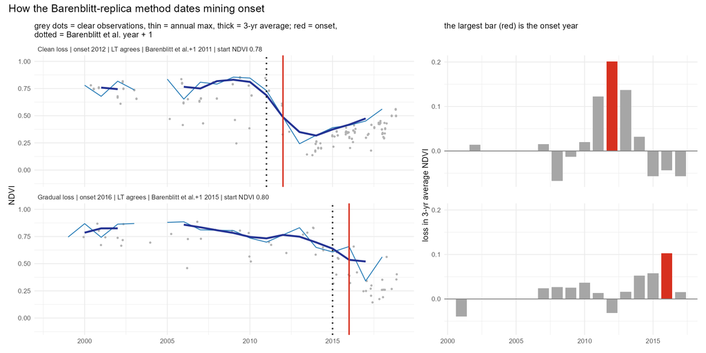

## 1.1 The imagery: Landsat 1998-2018

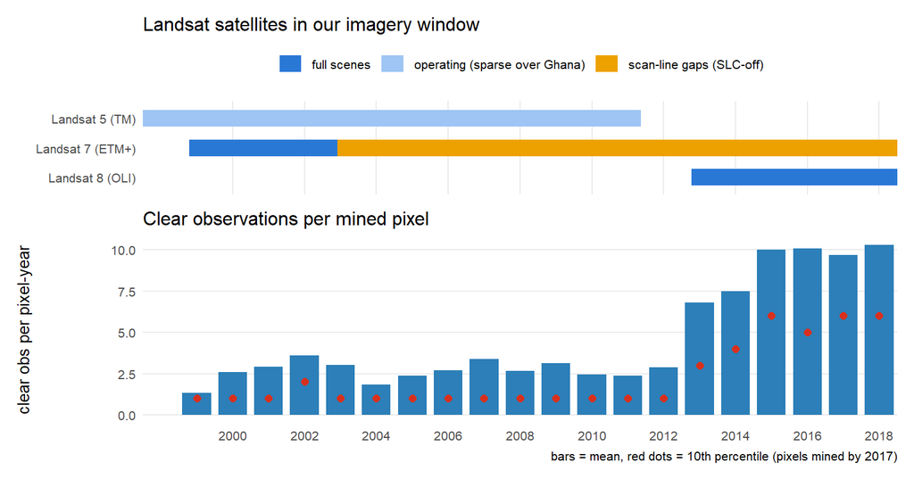

**Show more: alternative methods, the method step by step, rule e and the flags**

**Why this method over the alternatives**

Dating a land-cover change from a satellite time series is a standard problem in earth observation, and there are several ways to do it. We compare three: two widely used general-purpose change-detection algorithms, **LandTrendr** and **CCDC**, and the method **Barenblitt et al. (2021)** used to date galamsey in south-west Ghana. All three look for the break in a pixel’s vegetation record. They differ in how much imagery they need and in whether they always return a year.

We deploy the Barenblitt method with one fix for single-image years (rule e, Section 1.3) and keep LandTrendr as a confidence flag (`lt_agree`); Section 2.5 sets out why. **Naming:** “Barenblitt replica” means our implementation of their method; “Barenblitt et al.” means their published data.

**1.2 The Barenblitt method in detail**

For every pixel mined by 2017 (in the embeddings classifier’s 2017 mask, and confirmed by its 2018 mask):

1. Take every clear Landsat observation 1998-2018 and keep each year’s **maximum NDVI**.
2. Smooth with a **3-year centred moving average**.
3. Compute the **year-on-year loss** in that average.
4. The year with the **largest loss** is the onset year.

There is no minimum size of loss: every pixel gets a year. A year can only be scored if the pixel has clear observations in four consecutive years around it, so sparse early years limit which years can win. A clean forest-to-bare step shows up as equal losses in three consecutive years (from the smoothing). Our year label is the later one, which matches when the classifier first sees the mine (Section 2). Barenblitt et al. label the same loss one year earlier. The example figure above shows both cases: in the clean loss the largest bar is unambiguous; in the gradual loss the smoothing spreads it over several bars. Weak cases follow in Section 3.

**1.3 The deployed version: rule e and the credibility flags**

Step 1 takes each year’s greenest value. With several clear images a year, one hazy or cloudy image does not matter. With only one, that image *is* the year’s value, and if it is bad the pixel shows a fake one-year dip that step 4 then picks as the onset. Before 2013 a pixel has on average 3.5 such single-image years in 1998-2018; from 2013 almost none.

**Rule e** replaces the value of a single-image year by a linear interpolation between the nearest years with at least two clear images on either side. No year is dropped (dropping them removed real early onsets too and pushed every date later), and years with two or more images are untouched, so post-2013 dating is unchanged. Section 2.4 scores it.

The deployed asset also carries flags that the panel can use (full list in the appendix):

- **`persistent_loss`** (0/1): the pixel has at least one candidate year whose loss lasts, i.e. the median annual maximum NDVI over the 3 years after it is at least 0.15 below the median over the 3 years before. A dip that recovers fails. Imagery runs to 2020 for this check only, so 2015-2017 onsets get a full 3-year window. It barely changes *which* year is picked, but it separates reliable dates from unreliable ones (Section 2.4).
- **`onset_from2007`** with **`loss_from2007_x1000`**: the same rule-e dating restricted to 2007-2017, for the “no mining before 2007” convention (2007 = start of Barenblitt et al.’s dated series). A tiny post-2007 loss means the pixel was probably mined before 2007 and belongs in the starting stock.
- **`bare_pre2007`**: median annual maximum NDVI in 2004-2006 below 0.4, i.e. already bare going into 2007.
- **`n_interp_years`**: how many years rule e filled in.

# 2. Does it find the right year?

Apart from checking pixels by hand in historical imagery (not done yet), there are two ways to judge the methods, each with a caveat:

1. **Against the classifier’s own 2018-2025 conversions** (2.1, 2.2). Pixels the embeddings classifier first maps as mined in 2018-2025 have a known conversion year, independent of vegetation indices. But that year is the classifier’s first detection, not the true conversion year, and recent imagery is far denser than the early record. 2.2 therefore repeats the test with the imagery thinned to pre-2013 density.
2. **Against Barenblitt et al.’s published conversion years** (`classifica`, 2007-2017; 2.3). These cover the real historical imagery, but they come from the same NDVI method the Barenblitt replica copies, so the comparison is tilted in its favour.

## 2.1 Against the classifier’s 2018-2025 conversions

**Test:** pixels that first appear as mined in the embeddings classifier’s masks in 2018-2025 (and were not mined in 2017) get that first-detection year as a reference. Every method is then run on 2016-2026 Landsat imagery for the same pixels. Only pixels that stay mined in every mask after first detection are scored, since their reference year is the most reliable.

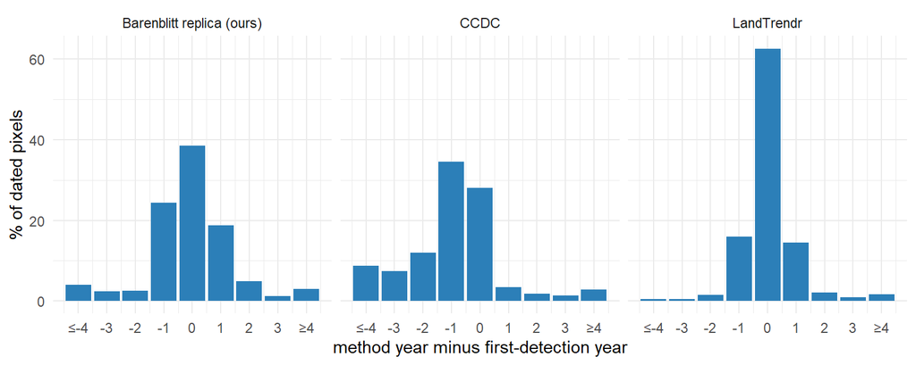

Script: `diag_04_groundtruth.R` · 40,692 pixels (37 km²)

**Show table**

| method | dated (%) | exact (%) | ±1 yr (%) | ±2 yr (%) | ±1 yr, share of all (%) | mean error (yr) |
| --- | --- | --- | --- | --- | --- | --- |
| Barenblitt replica (ours) | 100.0 | 38.6 | 81.7 | 89.3 | 81.7 | -0.07 |
| CCDC | 86.7 | 28.1 | 66.0 | 79.7 | 57.2 | -0.96 |
| LandTrendr | 27.1 | 62.6 | 93.0 | 96.7 | 25.3 | 0.08 |

**Reading it:** a peak at 0 means the year label lines up with when the classifier first sees the mine, so the backdated era (to 2017) and the embeddings era (2018 on) mean the same thing at the seam. This is a **best case** for imagery: 2018-2025 has about 10 clear observations per pixel per year, against 1-3 before 2013.

## 2.2 The same test with sparse imagery

The same test, with each pixel’s 2016-2026 imagery randomly thinned to about 2.5 clear observations per year, the pre-2013 average (some years end up with none, as in the early record). The gaps are random, whereas real early gaps cluster in the wet season.

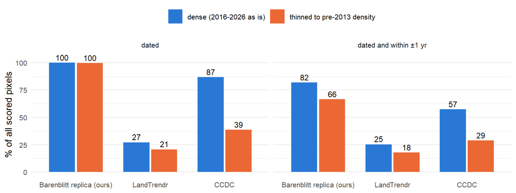

Script: `diag_04_groundtruth.R` (`THIN_TARGET = 2.5`)

**Show table**

| method | imagery | dated (%) | exact (%) | ±1 yr (%) | ±2 yr (%) | ±1 yr, share of all (%) | mean error (yr) |
| --- | --- | --- | --- | --- | --- | --- | --- |
| Barenblitt replica (ours) | dense | 100.0 | 38.6 | 81.7 | 89.3 | 81.7 | -0.07 |
| Barenblitt replica (ours) | thinned | 99.6 | 28.6 | 66.8 | 78.5 | 66.5 | -0.63 |
| CCDC | dense | 86.7 | 28.1 | 66.0 | 79.7 | 57.2 | -0.96 |
| CCDC | thinned | 38.6 | 36.9 | 74.6 | 86.1 | 28.8 | -0.69 |
| LandTrendr | dense | 27.1 | 62.6 | 93.0 | 96.7 | 25.3 | 0.08 |
| LandTrendr | thinned | 20.7 | 49.1 | 86.3 | 93.2 | 17.8 | -0.08 |

## 2.3 Against Barenblitt et al.’s conversion years

All three methods are run on the real historical imagery, on Barenblitt et al.’s own mapped footprint, so every one of their points can be scored and differences in what counts as “mined” don’t enter. Their years are shifted +1 to match our label convention (Section 1.2). Part of the Barenblitt replica’s agreement is mechanical, since it copies the method behind these years, and their years are not ground truth: they share the same imagery gaps and single-image artefacts.

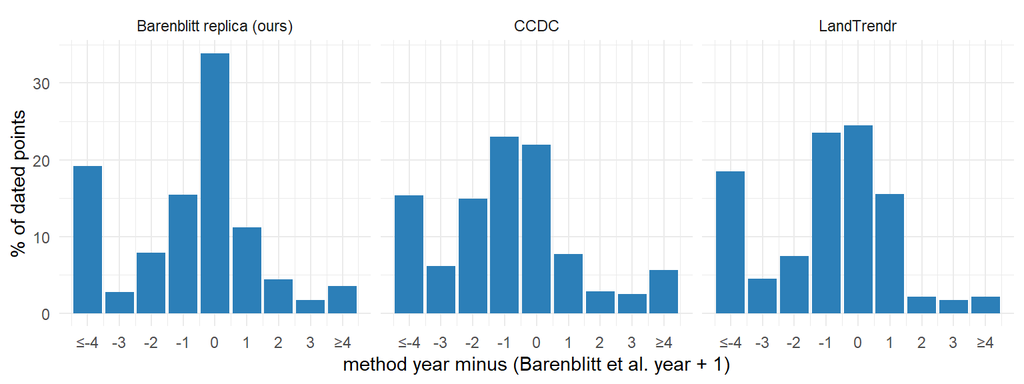

Script: `diag_04_method_fidelity.R` · 53,080 points on Barenblitt et al.’s 2019 footprint, 2007-2018 window

**Show table**

| method | points | dated (%) | exact (%) | ±1 yr (%) | ±2 yr (%) | ±1 yr, share of all (%) | mean error (yr) |
| --- | --- | --- | --- | --- | --- | --- | --- |
| Barenblitt replica (ours) | 53080 | 100.0 | 33.9 | 60.4 | 72.8 | 60.4 | -1.19 |
| CCDC | 53080 | 81.4 | 21.9 | 52.6 | 70.4 | 42.8 | -1.05 |
| LandTrendr | 53080 | 28.9 | 24.5 | 63.5 | 73.2 | 18.3 | -1.23 |

## 2.4 Rule e and the persistent-loss flag

**Rule e** (Section 1.3) is judged only on the embeddings test, whose reference years do not come from NDVI. With dense imagery it changes nothing, as intended. With imagery thinned to pre-2013 density it dates a few more pixels within ±1 year and fewer 4+ years too early (a fake early dip picked as the onset). The gain is modest. It is not scored against Barenblitt et al.’s years: those share the single-image artefacts that rule e removes, so agreement with them is not the goal.

Script: `diag_04_groundtruth.R` (`RULE_VARIANTS = c("e","f")`, Barenblitt et al. study area)

**Show table**

| imagery | method | dated (%) | exact (%) | ±1 yr (%) | ±2 yr (%) | ≥4 yr early (%) | mean error (yr) |
| --- | --- | --- | --- | --- | --- | --- | --- |
| dense | Barenblitt replica, plain | 100.0 | 39.8 | 83.1 | 90.2 | 3.7 | -0.11 |
| dense | Barenblitt replica + rule e (deployed) | 100.0 | 40.1 | 83.2 | 90.4 | 3.6 | -0.10 |
| thinned | Barenblitt replica, plain | 99.4 | 28.5 | 64.9 | 75.7 | 13.7 | -0.85 |
| thinned | Barenblitt replica + rule e (deployed) | 99.4 | 31.2 | 68.1 | 78.6 | 11.2 | -0.63 |

**The persistent-loss flag** marks which dates to trust. In the thinned test:

| pixels | share of pixels (%) | within ±1 yr (%) | ≥4 yr early (%) |
| --- | --- | --- | --- |
| no persistent loss | 19.3 | 35.8 | 33.3 |
| persistent loss | 80.7 | 75.5 | 6.1 |

## 2.5 Which method, then?

The panel needs an onset year for nearly every mined pixel, so what counts is the share of **all** pixels that are dated *and* dated within ±1 year, which combines coverage and accuracy:

- **Barenblitt replica (ours):** 82% with dense imagery, 66% thinned to pre-2013 density (dates 100% of pixels).
- **LandTrendr:** 25% with dense imagery, 18% thinned to pre-2013 density (dates 21% of pixels).
- **CCDC:** 57% with dense imagery, 29% thinned to pre-2013 density (dates 39% of pixels).

The Barenblitt replica is the only method that holds up when imagery is as sparse as before 2013, because it dates almost every pixel. LandTrendr is precise where it fires but leaves most pixels undated, so it serves as a confidence flag (`lt_agree`). CCDC needs several clear images per year and dates few pixels once the imagery is thinned. The replica also matches the method behind the only existing galamsey onset data.

# 3. What the backdating shows, and its weak spots

The deployed asset covers **638,053 pixels (574 km²)** mined by 2017 (confirmed in 2018), 99% of them inside Barenblitt et al.’s study area. **0.0%** could not be dated. **15%** are dated before 2007 (the starting stock under the robustness convention).

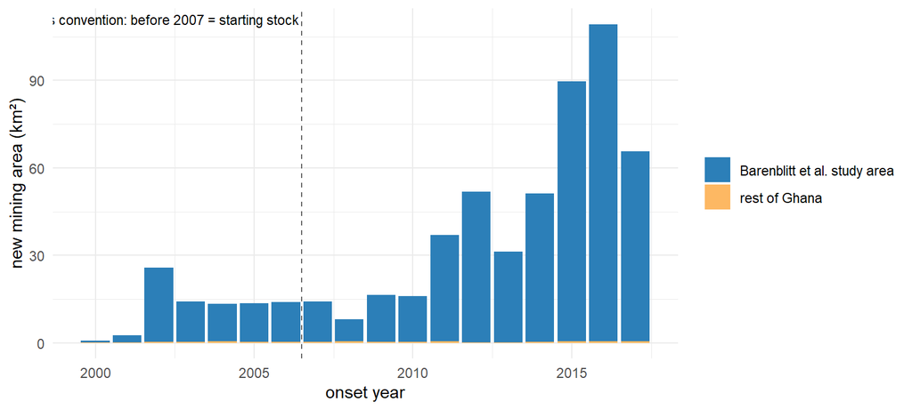

## 3.1 Our series against Barenblitt et al.’s data

Both series count **new** mining area per year inside Barenblitt et al.’s study area, from 2008 (their first year, shifted +1 to our label convention) to 2018. Ours is the backdated product to 2017 and the classifier’s first detections in 2018. The levels differ because the footprints differ (ours: everything the classifier maps as mined; theirs: their own map), so the shape over time is what to compare.

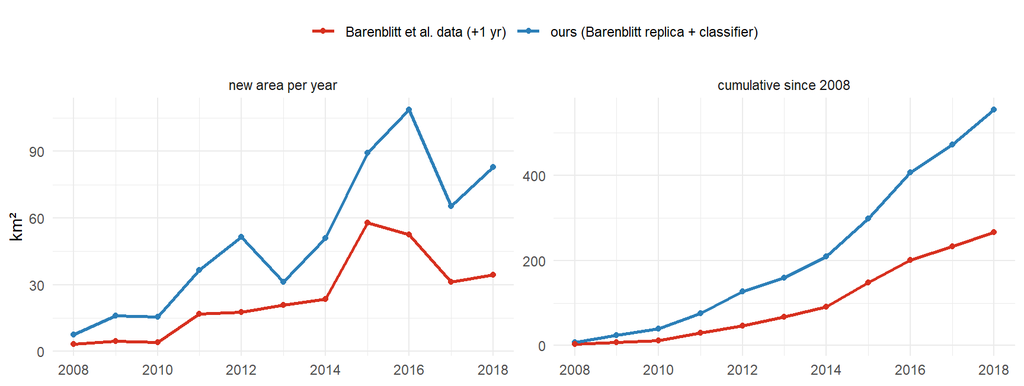

Correlation of new area per year, 2008-2018: r = 0.95.

## 3.2 The full series, 2000-2025

The backdated product (to 2017) joined with the classifier’s first confirmed detections (2018-2025). From 2017 on, both are cleaned by the temporal rule (Rule B: a status counts only when two consecutive years agree; see `diag_03_embedding_product_report`).

- **Bars:** new mining area per year, coloured by source.
- **Line:** the cumulative total of the bars, i.e. Option 1, “ever mined”: a pixel stays mined once it has been mined. This is the panel’s main spec.
- **White dots (2017-2025):** Option 2, “currently mined”. The same rule, but a pixel can exit after two years in a row of “not mine”. The gap between line and dots is land mined earlier that no longer shows as mined: revegetation, flooding or abandonment, not one-year flicker, which the rule removes.
- **2025** cannot be confirmed (no 2026 mask), so its bar is provisional.

Dashed lines mark 2007 (under the “no mining before 2007” convention, everything earlier becomes a starting stock) and the 2017/2018 seam between backdating and the classifier.

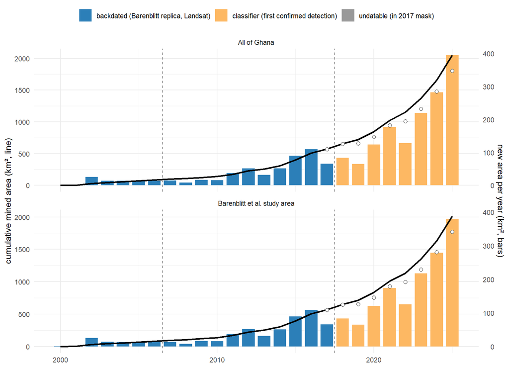

**Seam check:** cumulative backdated area through 2017 = 574 km², the 2017 classifier mask = 568 km² (1.2% apart; both come from the same mask, on slightly different 30 m grids).

**Show table: confidence flags by onset year**

Confidence flags by onset year, all of Ghana. Loss is ×1000 on the 3-yr average; 100 ≈ a sustained raw NDVI drop of 0.3.

| onset year | km² | LandTrendr agrees (%) | LandTrendr disagrees (%) | bare in 1998-2002 (%) | small loss <100 (%) | mean computable years | persistent loss (%) |
| --- | --- | --- | --- | --- | --- | --- | --- |
| 2000 | 0.7 | 5.6 | 3.0 | 74.2 | 58.1 | 16.0 | 49.2 |
| 2001 | 2.5 | 21.7 | 6.6 | 22.0 | 69.5 | 12.4 | 68.3 |
| 2002 | 25.7 | 6.7 | 12.6 | 4.7 | 66.6 | 11.5 | 75.4 |
| 2003 | 14.1 | 4.4 | 10.3 | 14.4 | 76.5 | 13.0 | 64.6 |
| 2004 | 13.4 | 5.3 | 9.3 | 5.9 | 80.6 | 13.4 | 66.5 |
| 2005 | 13.5 | 4.7 | 10.5 | 4.7 | 79.2 | 13.4 | 67.5 |
| 2006 | 14.0 | 6.8 | 8.5 | 3.8 | 82.3 | 13.0 | 67.3 |
| 2007 | 14.2 | 5.6 | 8.9 | 6.8 | 75.4 | 13.1 | 70.3 |
| 2008 | 8.1 | 8.2 | 6.7 | 29.7 | 77.7 | 12.9 | 71.4 |
| 2009 | 16.3 | 8.2 | 8.2 | 19.8 | 72.3 | 13.2 | 75.0 |
| 2010 | 15.9 | 18.4 | 5.0 | 7.0 | 60.9 | 13.7 | 76.3 |
| 2011 | 37.0 | 26.0 | 3.8 | 2.0 | 37.2 | 14.1 | 85.1 |
| 2012 | 51.7 | 41.6 | 2.3 | 1.4 | 20.9 | 13.9 | 94.6 |
| 2013 | 31.3 | 36.4 | 3.0 | 1.0 | 31.7 | 13.4 | 92.8 |
| 2014 | 51.2 | 30.0 | 3.2 | 1.5 | 35.0 | 12.4 | 90.1 |
| 2015 | 89.6 | 30.6 | 2.6 | 1.2 | 28.5 | 12.8 | 89.9 |
| 2016 | 109.2 | 29.9 | 2.9 | 1.5 | 31.2 | 12.6 | 88.5 |
| 2017 | 65.6 | 25.4 | 4.7 | 1.8 | 40.1 | 12.7 | 89.1 |

## 3.3 Why early dates are weaker

The confidence flags, grouped into three onset periods:

Confidence flags by onset period, all of Ghana (area-weighted).

| onset period | share of dated area (%) | persistent loss (%) | LandTrendr agrees (%) | LandTrendr disagrees (%) | LandTrendr: no break (%) | median loss (×1000) | loss <50 (%) | bare in 1998-2002 (%) |
| --- | --- | --- | --- | --- | --- | --- | --- | --- |
| 2000-2006 | 14.6 | 69.1 | 6.2 | 10.4 | 83.4 | 70 | 24.5 | 7.4 |
| 2007-2010 | 9.5 | 73.6 | 10.5 | 7.2 | 82.3 | 70 | 20.5 | 14.1 |
| 2011-2017 | 75.9 | 89.8 | 30.9 | 3.2 | 65.9 | 120 | 6.7 | 1.5 |

## 3.4 Weak spots, by example

Most weak spots trace back to the sparse early imagery (Section 1.1). Three example pixels: a one-year dip (a single low observation creates a false onset, the cause of the 2002 pile-up), a pixel that was already bare at the start (no real loss to find), and a pixel dated years before Barenblitt et al.’s year.

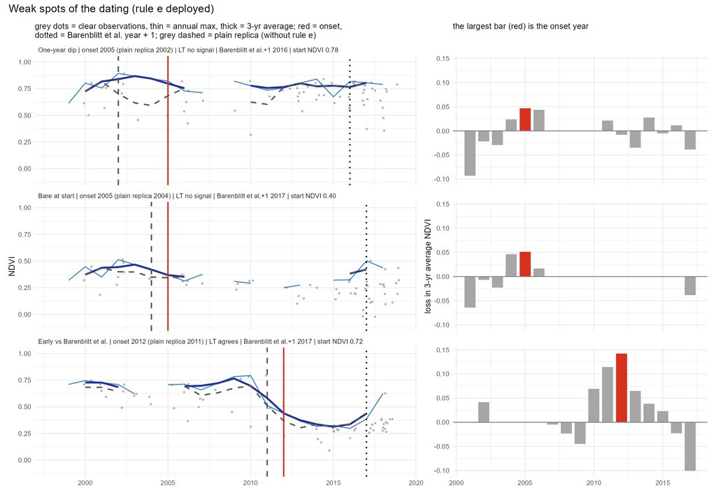

[output not shown]

# 4. Settings and why

| Setting | Value | Why |
| --- | --- | --- |
| Anchor footprint | embeddings mask, mined in 2017 and 2018 (Rule B) | one-off 2017 blips get no onset year; 2018+ onsets come from the classifier directly |
| Onset window | 2000-2017 | 2017 was cut off before (8.9% “undatable”) |
| Imagery | 1998-2018, full year (to 2020 for the persistence check only) | the 3-yr average needs a year either side; shortening it would misdate early mining |
| Single-image years | interpolated from the nearest ≥2-image years (rule e) | removes fake one-year dips without dropping any year (Sections 1.3, 2.4) |
| Year label | later year of the loss | matches the classifier’s first detection (Section 2) |
| Minimum loss | none | no natural cut-off; a threshold biases the timeline |
| Persistent loss | 3-yr median after ≥ 0.15 below 3-yr median before | flag only; separates credible from shaky dates |
| Later convention | onsets from 2007 | start of Barenblitt et al.’s dated series |
| LandTrendr (cross-check) | mag > 200, dur < 4, pre-value > 100 | Barenblitt et al.’s comparison settings |

# Appendix: deployed asset bands

`mine_onset_year_2000_2017_rulee`, 30 m (replaces `mine_onset_year_2000_2017_barenblitt`, which is kept). It was built on the raw 2017 anchor. `diag_04_backdating.R` and `b_04` mask it to the confirmed anchor (`cur_2017` of `mine_status_ghana_c4_ruleB_2017_2025`), which is equivalent to rebuilding it, since every pixel is dated on its own.

| Band | Meaning | No-data value |
| --- | --- | --- |
| `onset_year` | rule-e onset year, 2000-2017 | 0 = not datable |
| `ndvi_deriv_x1000` | size of the winning loss, ×1000 | -9999 |
| `onset_from2007` | rule-e onset restricted to 2007-2017 | 0 |
| `loss_from2007_x1000` | size of that loss, ×1000 | -9999 |
| `persistent_loss` | 1 = some loss persists 3 years (Section 1.3) | – |
| `reference_tier` | 0 = onset before 2007, 1 = 2007+ (comparable with Barenblitt et al.’s years) | 9 |
| `lt_agree` | 0 LandTrendr agrees ±2 yr, 1 disagrees, 2 no LandTrendr signal | 9 |
| `n_obs_years` | years 1998-2018 with ≥1 clear observation | – |
| `n_computable_years` | candidate years that could be scored | – |
| `n_interp_years` | years 1998-2018 filled in by rule e | – |
| `bare_pre2007` | 1 = median annual max NDVI 2004-2006 < 0.4 | 9 |
| `start_ndvi_x1000` | median rule-e annual max NDVI 1998-2002, ×1000 | -9999 |

Sources: CSVs and figures in `outputs/tables/backdating/` and `outputs/figures/backdating/`, produced by `build_04_backdating.R`, `diag_04_groundtruth.R`, `diag_04_method_fidelity.R` and `diag_04_backdating.R`.